# DMTM Project FA22

Benjamin Dinal, David Schindler

# Library & Data Loading; General Statistics & Summary

```r
library(topicdoc)
library(topicmodels)
library(tidyverse)
library(tidytext)
library(dplyr)
library(ggplot2)
library(mosaic)
library(RColorBrewer)
library(wordcloud)
library(reshape2)
```

```r
DL <- read.csv("DisneylandReviews.csv")
DLReview <- (select(DL, Review_ID, Rating, Year, Year_Month, Reviewer_Continent, Reviewer_Country, Review_Text, Branch))
```

This dataset consists of over 40000 reviews from TripAdvisor for Disneyland Paris, Hong Kong, and California. The dataset was downloaded via Kaggle, and cleaned client-side.

```r
head(DLReview)
```

|  | Review_ID | Rating | Year | Year_Month | Reviewer_Continent | Reviewer_Country | Review_Text | Branch |
| --- | --- | --- | --- | --- | --- | --- | --- | --- |
| 1 | 670801367 | 5 | 2019 | 2019-4 | North America | United States | This place has always been and forever will be special. The feeling you get entering the park, seeing the characters and different attractions is just priceless. This is definitely a dream trip for al… | Disneyland_California |
| 2 | 670760708 | 5 | 2019 | 2019-4 | North America | United States | A great day of simple fun and thrills. Bring cash, nothing is cheap, but we knew that it's Disney. But they are great letting you bring in your own food, drinks, etc but read the list closely, we list… | Disneyland_California |
| 3 | 670565072 | 4 | 2019 | 2019-5 | Oceania | Australia | All and all a great day was had. The crowds are huge and ride times sometimes up to a 50 min wait but worth it. Very disappointed the castle was under repair and covered but we understood. If you want… | Disneyland_California |
| 4 | 670544335 | 5 | 2019 | 2019-4 | North America | United States | Having been to the Florida location numerous times over the years I didn't know how this one would compare. The much smaller footprint made it quicker easier to get from ride to ride. The Cinderella's… | Disneyland_California |
| 5 | 670472278 | 5 | 2019 | 2019-4 | North America | Canada | Had the 4 day pass, spent 3 at DL and one at CA. Great place to visit. We will be back. Saw a lot in those days, but there is more that we missed, and more we want to see again. | Disneyland_California |
| 6 | 670382191 | 5 | 2019 | 2019-4 | Asia | Lebanon | Oh my god you can really forget your self and enjoy everything you face there its a huge word of fun | Disneyland_California |

```r
DLReview %>%
  count(Branch, sort = TRUE)
```

| Branch | n |
| --- | --- |
| Disneyland_California | 18200 |
| Disneyland_Paris | 12693 |
| Disneyland_HongKong | 9138 |

```r
DLReview %>%
  count(Rating)
```

| Rating | n |
| --- | --- |
| 1 | 1338 |
| 2 | 1929 |
| 3 | 4780 |
| 4 | 10082 |
| 5 | 21902 |

```r
DLReview %>%
  count(Review_ID, sort = TRUE)
```

| Review_ID | n |
| --- | --- |
| 121615136 | 2 |
| 121615246 | 2 |
| 164830205 | 2 |
| 166730734 | 2 |
| 166753649 | 2 |
| 166787525 | 2 |
| 166787635 | 2 |
| 168489234 | 2 |
| 91619113 | 1 |
| 91639166 | 1 |

[output cut: 990 more lines]

```r
DLReview %>%
  count(Reviewer_Continent)
```

| Reviewer_Continent | n |
| --- | --- |
| Africa | 429 |
| Asia | 6708 |
| Europe | 11731 |
| North America | 15826 |
| Oceania | 5157 |
| South America | 180 |

Most Reviewers are from North America, having 15826 reviews. Europe has 11731, and Asia has 6708.

18200 reviews are for Disneyland CA, 12693 are for Disneyland Paris, and 9138 are for Disneyland HK.

More than half of the entire data set consists of 5 Star reviews.

# Data Manipulation

We are going to partition the data into 3 regions: North America and South America will combine, Europe and Africa will combine, and Oceania and Asia will combine.

```r
DLR_Amer <- DLReview %>%
  filter((Reviewer_Continent == "North America")|(Reviewer_Continent=="South America")) %>%
  unnest_tokens(word, Review_Text) %>%
  anti_join(stop_words)
head(DLR_Amer)
```

|  | Review_ID | Rating | Year | Year_Month | Reviewer_Continent | Reviewer_Country | Branch | word |
| --- | --- | --- | --- | --- | --- | --- | --- | --- |
| 1 | 670801367 | 5 | 2019 | 2019-4 | North America | United States | Disneyland_California | forever |
| 2 | 670801367 | 5 | 2019 | 2019-4 | North America | United States | Disneyland_California | special |
| 3 | 670801367 | 5 | 2019 | 2019-4 | North America | United States | Disneyland_California | feeling |
| 4 | 670801367 | 5 | 2019 | 2019-4 | North America | United States | Disneyland_California | entering |
| 5 | 670801367 | 5 | 2019 | 2019-4 | North America | United States | Disneyland_California | park |
| 6 | 670801367 | 5 | 2019 | 2019-4 | North America | United States | Disneyland_California | characters |

```r
DLR_AfEu <- DLReview %>%
  filter((Reviewer_Continent == "Africa")|(Reviewer_Continent=="Europe")) %>%
  unnest_tokens(word, Review_Text) %>%
  anti_join(stop_words)
head(DLR_AfEu)
```

|  | Review_ID | Rating | Year | Year_Month | Reviewer_Continent | Reviewer_Country | Branch | word |
| --- | --- | --- | --- | --- | --- | --- | --- | --- |
| 1 | 668734266 | 5 | 2019 | 2019-4 | Europe | United Kingdom | Disneyland_California | found |
| 2 | 668734266 | 5 | 2019 | 2019-4 | Europe | United Kingdom | Disneyland_California | park |
| 3 | 668734266 | 5 | 2019 | 2019-4 | Europe | United Kingdom | Disneyland_California | provide |
| 4 | 668734266 | 5 | 2019 | 2019-4 | Europe | United Kingdom | Disneyland_California | family |
| 5 | 668734266 | 5 | 2019 | 2019-4 | Europe | United Kingdom | Disneyland_California | friendly |
| 6 | 668734266 | 5 | 2019 | 2019-4 | Europe | United Kingdom | Disneyland_California | fun |

```r
DLR_AsOc <- DLReview %>%
  filter((Reviewer_Continent == "Asia")|(Reviewer_Continent=="Oceania")) %>%
  unnest_tokens(word, Review_Text) %>%
  anti_join(stop_words)
head(DLR_AsOc)
```

|  | Review_ID | Rating | Year | Year_Month | Reviewer_Continent | Reviewer_Country | Branch | word |
| --- | --- | --- | --- | --- | --- | --- | --- | --- |
| 1 | 670565072 | 4 | 2019 | 2019-5 | Oceania | Australia | Disneyland_California | day |
| 2 | 670565072 | 4 | 2019 | 2019-5 | Oceania | Australia | Disneyland_California | crowds |
| 3 | 670565072 | 4 | 2019 | 2019-5 | Oceania | Australia | Disneyland_California | huge |
| 4 | 670565072 | 4 | 2019 | 2019-5 | Oceania | Australia | Disneyland_California | ride |
| 5 | 670565072 | 4 | 2019 | 2019-5 | Oceania | Australia | Disneyland_California | times |
| 6 | 670565072 | 4 | 2019 | 2019-5 | Oceania | Australia | Disneyland_California | 50 |

# Sentiment Analysis on All Three Disneyland Parks Partitioned by Region

## Region - The Americas

Now we will perform Sentiment Analysis using the “Bing” lexicon on each region’s reviews. First, this will be a Sentiment Analysis of all three Disneyland Parks combined (HK, CA, PR)

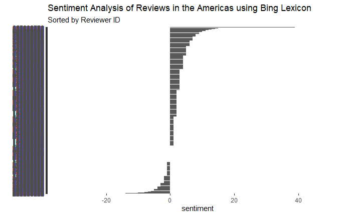

```r
DLR_Amer %>%
  inner_join(get_sentiments("bing")) %>%
  count(Review_ID, sentiment) %>%
  spread(sentiment, n, fill = 0) %>%
  mutate(sentiment = positive - negative) %>%
  ggplot() +
  geom_bar(aes(x = reorder(Review_ID, sentiment),
               y = sentiment),
           stat = "identity") +
  coord_flip() +
  labs(x = "",
       title = "Sentiment Analysis of Reviews in the Americas using Bing Lexicon",
       subtitle = "Sorted by Reviewer ID")
```

While difficult to read, this Sentiment Analysis shows that an overwhelming majority of Reviewers had positive things to say. This is beneficial because it aligns with the Stars Ratings - more than half of the data-set is 5 star reviews, and more than half of this sample contains a positive sentiment.

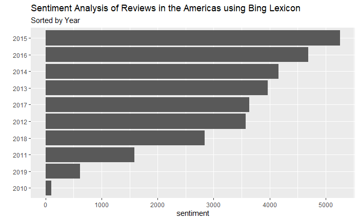

```r
DLR_Amer %>%
  inner_join(get_sentiments("bing")) %>%
  count(Year, sentiment) %>%
  spread(sentiment, n, fill = 0) %>%
  mutate(sentiment = positive - negative) %>%
  ggplot() +
  geom_bar(aes(x = reorder(Year, sentiment),
               y = sentiment),
           stat = "identity") +
  coord_flip() +
  labs(x = "",
       title = "Sentiment Analysis of Reviews in the Americas using Bing Lexicon",
       subtitle = "Sorted by Year")
```

In this sentiment analysis, we see that 2015 had an overwhelmingly high sentiment score. This can be attributed to the fact that, for the America’s, Disneyland California celebrated it’s 60th Year Anniversary. However, if we were to exclude Disneyland California, 2017’s sentiment score is the highest.

##Sentimental analysis with *nrc* lexicon

```r
DLR_Amer_lo_words <- DLR_Amer%>%
  inner_join(get_sentiments("nrc")) %>%
  group_by(sentiment, word) %>%
  count(mycount = n()) %>%
  distinct() %>%
  filter(sentiment %in%
  c("anger", "fear", "anticipation", "trust", "surprise", "sadness", "joy", "disgust"))
head(DLR_Amer_lo_words)
```

| sentiment | word | mycount | n |
| --- | --- | --- | --- |
| anger | abandoned | 362127 | 10 |
| anger | abolish | 362127 | 1 |
| anger | abomination | 362127 | 1 |
| anger | abuse | 362127 | 15 |
| anger | accused | 362127 | 5 |
| anger | accusing | 362127 | 1 |

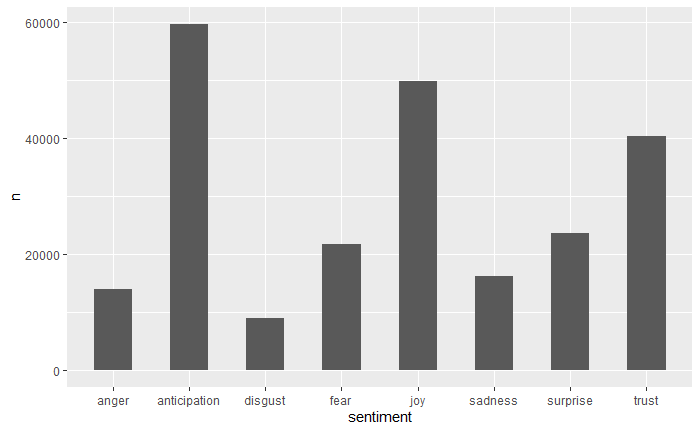

```r
ggplot(DLR_Amer_lo_words, aes(x=sentiment, y=n)) +
  geom_bar(stat="identity", width=0.5)
```

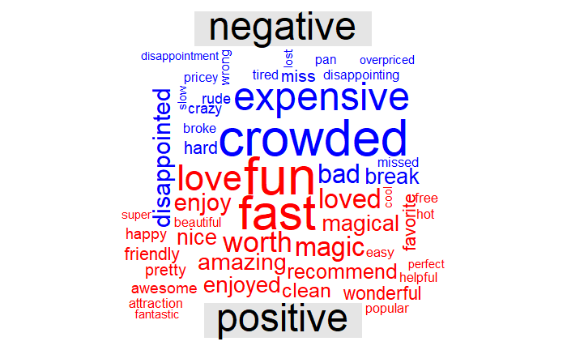

```r
DLR_Amer_wordcloud_sentiment <- DLR_Amer %>%
  inner_join(get_sentiments("bing")) %>%
  count(word, sentiment, sort = TRUE) %>%
  acast(word~sentiment, value.var ="n", fill=0) %>%
  comparison.cloud(colors = c("blue","red"), max.words = 50)
```

## Region: Euorpe and Africa

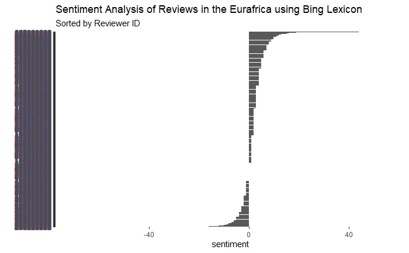

```r
DLR_AfEu %>%
  inner_join(get_sentiments("bing")) %>%
  count(Review_ID, sentiment) %>%
  spread(sentiment, n, fill = 0) %>%
  mutate(sentiment = positive - negative) %>%
  ggplot() +
  geom_bar(aes(x = reorder(Review_ID, sentiment),
               y = sentiment),
           stat = "identity") +
  coord_flip() +
  labs(x = "",
       title = "Sentiment Analysis of Reviews in the Eurafrica using Bing Lexicon",
       subtitle = "Sorted by Reviewer ID")
```

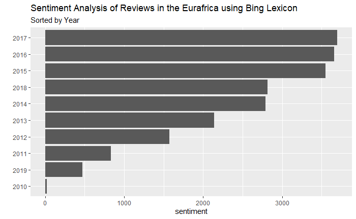

```r
DLR_AfEu %>%
  inner_join(get_sentiments("bing")) %>%
  count(Year, sentiment) %>%
  spread(sentiment, n, fill = 0) %>%
  mutate(sentiment = positive - negative) %>%
  ggplot() +
  geom_bar(aes(x = reorder(Year, sentiment),
               y = sentiment),
           stat = "identity") +
  coord_flip() +
  labs(x = "",
       title = "Sentiment Analysis of Reviews in the Eurafrica using Bing Lexicon",
       subtitle = "Sorted by Year")
```

```r
DLR_AfEu_lo_words <- DLR_AfEu%>%
  inner_join(get_sentiments("nrc")) %>%
  group_by(sentiment, word) %>%
  count(mycount = n()) %>%
  distinct() %>%
  filter(sentiment %in%
  c("anger", "fear", "anticipation", "trust", "surprise", "sadness", "joy", "disgust"))
head(DLR_AfEu_lo_words)
```

| sentiment | word | mycount | n |
| --- | --- | --- | --- |
| anger | abandoned | 349208 | 13 |
| anger | abandonment | 349208 | 1 |
| anger | abhor | 349208 | 1 |
| anger | abhorrent | 349208 | 1 |
| anger | abomination | 349208 | 2 |
| anger | abuse | 349208 | 13 |

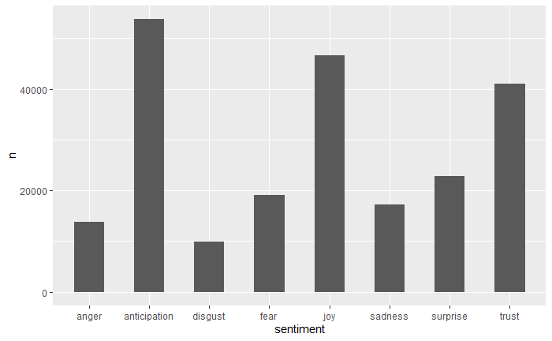

```r
ggplot(DLR_AfEu_lo_words, aes(x=sentiment, y=n)) +
  geom_bar(stat="identity", width=0.5)
```

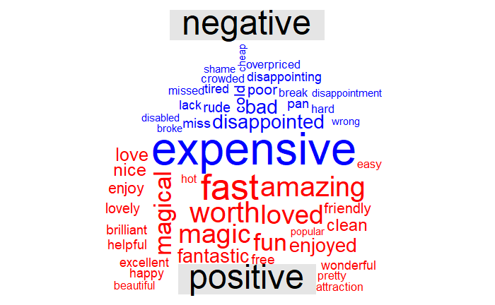

```r
DLR_AfEu_wordcloud_sentiment <- DLR_AfEu %>%
  inner_join(get_sentiments("bing")) %>%
  count(word, sentiment, sort = TRUE) %>%
  acast(word~sentiment, value.var ="n", fill=0) %>%
  comparison.cloud(colors = c("blue","red"), max.words = 50)
```

## Region: Asia and Oceania

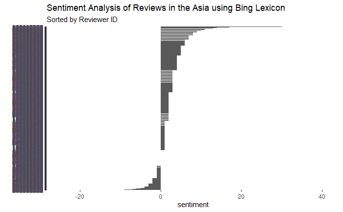

```r
DLR_AsOc %>%
  inner_join(get_sentiments("bing")) %>%
  count(Review_ID, sentiment) %>%
  spread(sentiment, n, fill = 0) %>%
  mutate(sentiment = positive - negative) %>%
  ggplot() +
  geom_bar(aes(x = reorder(Review_ID, sentiment),
               y = sentiment),
           stat = "identity") +
  coord_flip() +
  labs(x = "",
       title = "Sentiment Analysis of Reviews in the Asia using Bing Lexicon",
       subtitle = "Sorted by Reviewer ID")
```

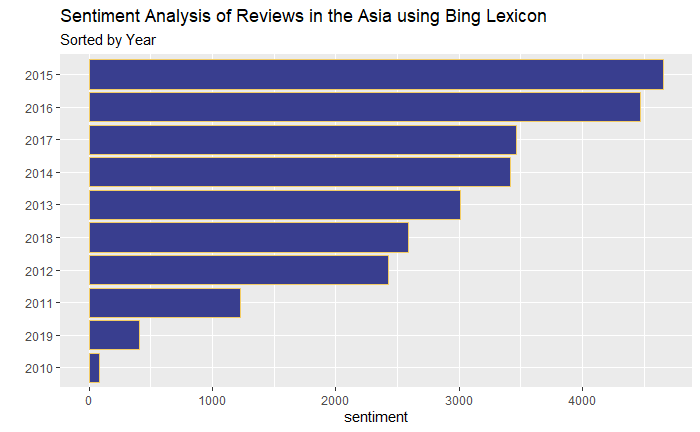

```r
DLR_AsOc %>%
  inner_join(get_sentiments("bing")) %>%
  count(Year, sentiment) %>%
  spread(sentiment, n, fill = 0) %>%
  mutate(sentiment = positive - negative) %>%
  ggplot() +
  geom_bar(aes(x = reorder(Year, sentiment),
               y = sentiment),
           stat = "identity", fill="#393E8F", color="#F3CC64") +
  coord_flip() +
  labs(x = "",
       title = "Sentiment Analysis of Reviews in the Asia using Bing Lexicon",
       subtitle = "Sorted by Year")
```

```r
DLR_AsOc_lo_words <- DLR_AsOc%>%
  inner_join(get_sentiments("nrc")) %>%
  group_by(sentiment, word) %>%
  count(mycount = n()) %>%
  distinct() %>%
  filter(sentiment %in%
  c("anger", "fear", "anticipation", "trust", "surprise", "sadness", "joy", "disgust"))
head(DLR_AsOc_lo_words)
```

| sentiment | word | mycount | n |
| --- | --- | --- | --- |
| anger | abandoned | 238611 | 4 |
| anger | abandonment | 238611 | 1 |
| anger | abuse | 238611 | 1 |
| anger | adverse | 238611 | 2 |
| anger | aftermath | 238611 | 1 |
| anger | aggravated | 238611 | 1 |

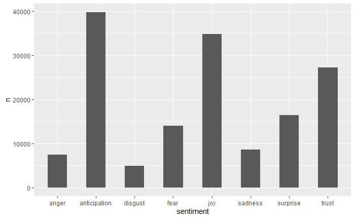

```r
ggplot(DLR_AsOc_lo_words, aes(x=sentiment, y=n)) +
  geom_bar(stat="identity", width=0.5)
```

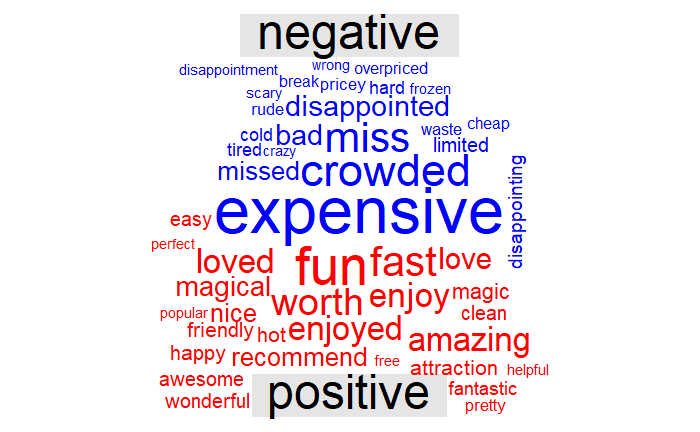

```r
DLR_AsOc_wordcloud_sentiment <- DLR_AsOc %>%
  inner_join(get_sentiments("bing")) %>%
  count(word, sentiment, sort = TRUE) %>%
  acast(word~sentiment, value.var ="n", fill=0) %>%
  comparison.cloud(colors = c("blue","red"), max.words = 50)
```